# OSMtidy - Vignette 5, Post-processing

Dr Annie Visser-Quinn, a.visser-quinn@hw.ac.uk

2020-08-13

## 1. Introduction

This final vignette introduces OSMtidy’s (optional) post-processing functions:

- `makeValid()` attempts to make all geometries valid as well as recasting multigeometries to their component parts
- A family of functions for simplifying geometries related to golf, rail and airports
- `exportOSMtidy()` exports the post-processed data as a spreadsheet, an RDS file or a series of shapefiles

This vignette will walk through these functions for two cities: Manchester and Edinburgh. These inputs are available in the folder *vignettes/files/postProcessing*.

## 2. Example one - Manchester

```r
file <- list.files("vignettes/files/postProcessing", pattern = "Manchester", full.names = TRUE)
file
```

```
#> [1] "vignettes/files/postProcessing/Manchester_City_6_dataTidy-filtered_20200712-170959.RDS"
```

```r
# Read RDS files into R using the base R function readRDS()
dm <- readRDS(file)
dm
```

```
#> # A tibble: 58,824 x 3
#>    osm_id   desc                                                        geometry
#>    <chr>    <chr>                                               <LINESTRING [°]>
#>  1 3895636  Transport infrastructur~    (-2.281549 53.34606, -2.279685 53.34696)
#>  2 4232478  Transport infrastructur~ (-2.278362 53.3486, -2.27842 53.34866, -2.~
#>  3 4232479  Transport infrastructur~ (-2.276804 53.3506, -2.276921 53.35051, -2~
#>  4 4232481  Transport infrastructur~ (-2.274688 53.3498, -2.274816 53.3503, -2.~
#>  5 4232482  Transport infrastructur~ (-2.272847 53.35052, -2.272565 53.35135, -~
#>  6 4232524  Transport infrastructur~ (-2.284455 53.34647, -2.284356 53.34662, -~
#>  7 4232525  Transport infrastructur~ (-2.282267 53.34622, -2.282192 53.3463, -2~
#>  8 1650301~ Barrier; Wall            (-2.263275 53.47579, -2.263011 53.47575, -~
#>  9 4196721~ Barrier; Wall               (-2.251842 53.52569, -2.251777 53.52567)
#> 10 4196722~ Barrier; Wall               (-2.251895 53.52564, -2.251853 53.52563)
#> # ... with 58,814 more rows
```

### 2.1 makeValid()

The function `makeValid()` attempts to validate the output geometries and resolve any spatial errors when using the geodata. The function consists of two parts. First, the function attempts to validate the geometries using the `st_make_valid()` function from the R package `sf`. This first part return a list split by geometry type. The second part looks at each type of geometry, attempts to recast it as a simpler geometry, and attempts to make this final output valid.

**Note** If the function finds multiple errors, it will attempt to run a longer (and hence slower) code.

```r
dm %>% nrow()
```

```
#> [1] 58824
```

```r
dm <- dm %>% makeValid
dm
```

```
#> Simple feature collection with 59115 features and 2 fields
#> geometry type:  GEOMETRY
#> dimension:      XY
#> bbox:           xmin: -2.319909 ymin: 53.3401 xmax: -2.146829 ymax: 53.54459
#> geographic CRS: WGS 84
#> First 10 features:
#>                                        desc       type
#> 1                          Amenity; Parking LINESTRING
#> 2                          Amenity; Parking LINESTRING
#> 3       Sports and games; Recreation ground LINESTRING
#> 4                               Residential LINESTRING
#> 5  Outdoors and natural environment; Meadow LINESTRING
#> 6  Outdoors and natural environment; Meadow LINESTRING
#> 7  Outdoors and natural environment; Meadow LINESTRING
#> 8                               Residential LINESTRING
#> 9                               Residential LINESTRING
#> 10                              Residential LINESTRING
#>                          geometry
#> 1  LINESTRING (-2.295983 53.36...
#> 2  LINESTRING (-2.295983 53.36...
#> 3  LINESTRING (-2.291281 53.43...
#> 4  LINESTRING (-2.164058 53.49...
#> 5  LINESTRING (-2.299762 53.38...
#> 6  LINESTRING (-2.299762 53.38...
#> 7  LINESTRING (-2.299479 53.38...
#> 8  LINESTRING (-2.214654 53.40...
#> 9  LINESTRING (-2.215477 53.41...
#> 10 LINESTRING (-2.214901 53.41...
```

```r
dm %>% nrow()
```

```
#> [1] 59115
```

### 2.2 Simplify

Three functions have been developed to further simplify golf, rail and airport objects. These should be applied *after* the application of `makeValid()`. Each function is optional - you may use one, none, or any combination of the three.

#### simplifyGolf()

The default filters in *filters.xlsx* result in an output such as that shown in the figure below. The sand traps / bunkers are shown as well as the outline of the golf course in its entirety. Buildings might also be outlined. Filters for physical objects relating to golf are challenging: driving ranges and other key buildings tend to be removed. The purpose of the `simplifyGolf()` function is to identify which objects belong to the same golf course, and then reduce them to a single polygon.

You can code variations for other object types by following the same structure and using the internal function `simplifyIntersects()`.

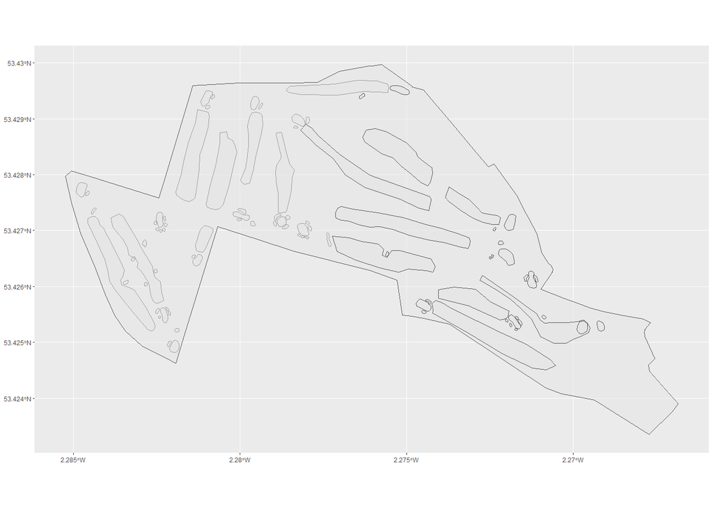

```r
example_golfBefore
```

The function accepts the following arguments:

- *dg* The valid geodata as a spatial feature
- *descSearch = “(golf)”* The search term to identify the related objects
- *descNew = “Sports and games; Golf”* A new descriptor to assign to the objects once simplified
- *maxIterations = 100* The function is applied iteratively and stops once all objects have been simplified or *maxIterations* is reached
- *rbind = TRUE* Should the simplified objects be provided as the output (FALSE) or bound to the filtered input (TRUE)

```r
golfBefore <- dm %>% filter(str_detect(desc, "(golf)"))
golfAfter <- dm %>% simplifyGolf(rbind = FALSE)

golfBefore
```

```
#> Simple feature collection with 323 features and 2 fields
#> geometry type:  GEOMETRY
#> dimension:      XY
#> bbox:           xmin: -2.285231 ymin: 53.39896 xmax: -2.180675 ymax: 53.54388
#> geographic CRS: WGS 84
#> First 10 features:
#>                                                       desc       type
#> 1                Sports and games; Outdoor facility (golf) LINESTRING
#> 2                Sports and games; Outdoor facility (golf)    POLYGON
#> 3  Sports and games; Clubhouse and outdoor facility (golf)    POLYGON
#> 4  Sports and games; Clubhouse and outdoor facility (golf)    POLYGON
#> 5  Sports and games; Clubhouse and outdoor facility (golf)    POLYGON
#> 6  Sports and games; Clubhouse and outdoor facility (golf)    POLYGON
#> 7  Sports and games; Clubhouse and outdoor facility (golf)    POLYGON
#> 8  Sports and games; Clubhouse and outdoor facility (golf)    POLYGON
#> 9  Sports and games; Clubhouse and outdoor facility (golf)    POLYGON
#> 10 Sports and games; Clubhouse and outdoor facility (golf)    POLYGON
#>                          geometry
#> 1  LINESTRING (-2.253614 53.41...
#> 2  POLYGON ((-2.253614 53.4141...
#> 3  POLYGON ((-2.200585 53.4249...
#> 4  POLYGON ((-2.199433 53.4267...
#> 5  POLYGON ((-2.193292 53.4276...
#> 6  POLYGON ((-2.19317 53.42829...
#> 7  POLYGON ((-2.192558 53.4308...
#> 8  POLYGON ((-2.187284 53.5295...
#> 9  POLYGON ((-2.180675 53.5283...
#> 10 POLYGON ((-2.249841 53.5358...
```

```r
golfAfter
```

```
#> Simple feature collection with 17 features and 2 fields
#> geometry type:  POLYGON
#> dimension:      XY
#> bbox:           xmin: -2.285231 ymin: 53.39896 xmax: -2.180675 ymax: 53.54388
#> geographic CRS: WGS 84
#> First 10 features:
#>                      desc    type                       geometry
#> 1  Sports and games; Golf POLYGON POLYGON ((-2.255187 53.4125...
#> 2  Sports and games; Golf POLYGON POLYGON ((-2.276133 53.4299...
#> 3  Sports and games; Golf POLYGON POLYGON ((-2.249841 53.5358...
#> 4  Sports and games; Golf POLYGON POLYGON ((-2.284672 53.4074...
#> 5  Sports and games; Golf POLYGON POLYGON ((-2.244124 53.5365...
#> 6  Sports and games; Golf POLYGON POLYGON ((-2.244042 53.4087...
#> 7  Sports and games; Golf POLYGON POLYGON ((-2.244028 53.4152...
#> 8  Sports and games; Golf POLYGON POLYGON ((-2.200585 53.4249...
#> 9  Sports and games; Golf POLYGON POLYGON ((-2.199433 53.4267...
#> 10 Sports and games; Golf POLYGON POLYGON ((-2.193292 53.4276...
```

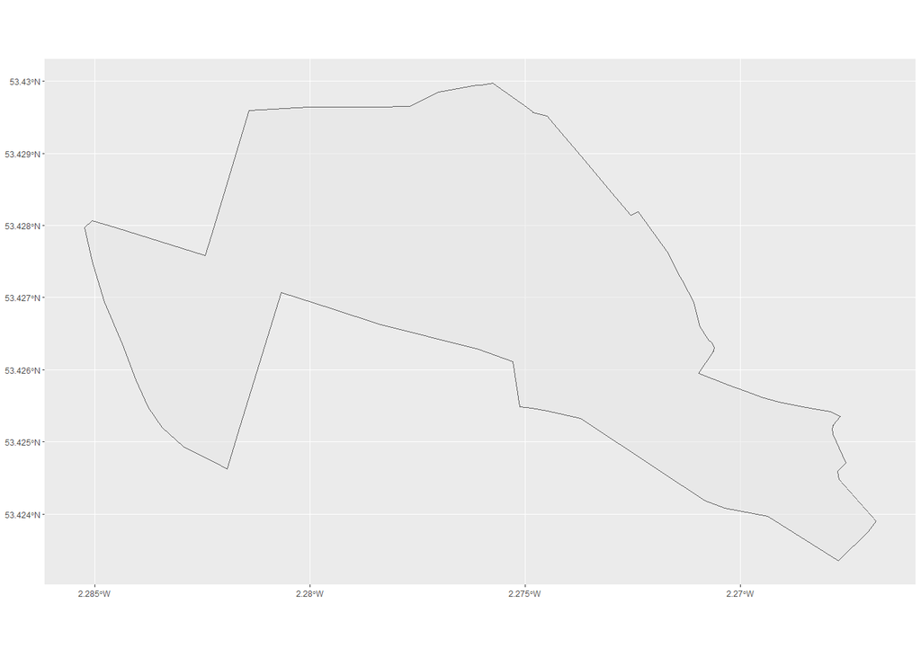

```r
example_golfAfter
```

```r
dm %>% nrow()
```

```
#> [1] 59115
```

```r
dm <- dm %>% simplifyGolf(rbind = TRUE)
dm %>% nrow()
```

```
#> [1] 58809
```

```r
dm %>% tail
```

```
#> Simple feature collection with 6 features and 2 fields
#> geometry type:  POLYGON
#> dimension:      XY
#> bbox:           xmin: -2.249883 ymin: 53.39896 xmax: -2.180675 ymax: 53.53523
#> geographic CRS: WGS 84
#>                         desc    type                       geometry
#> 58804 Sports and games; Golf POLYGON POLYGON ((-2.192558 53.4308...
#> 58805 Sports and games; Golf POLYGON POLYGON ((-2.187284 53.5295...
#> 58806 Sports and games; Golf POLYGON POLYGON ((-2.180675 53.5283...
#> 58807 Sports and games; Golf POLYGON POLYGON ((-2.249883 53.5343...
#> 58808 Sports and games; Golf POLYGON POLYGON ((-2.247581 53.4017...
#> 58809 Sports and games; Golf POLYGON POLYGON ((-2.244776 53.4112...
```

#### simplifyRail()

This function focuses on rail stations. It eliminates point geometries which duplicate polygons and, through specification of an area threshold, determines which polygons are major or minor stations. The default values have been determined with reference to three cities: Edinburgh, Manchester and Bristol.

You can code variations for other object types by following the same structure and using the internal function `simplifyPoints()`.

The function accepts the following arguments:

- *dg* The valid geodata as a spatial feature
- *descSearch = “Rail station”* The search term to identify the related objects
- *descNew = “Public transport; Rail station”* A new descriptor to assign to the objects once simplified; major and minor stations will be specified by a suffix
- *threshold_distance = 1000* Distance, in metres, below which objects should be considered as a single rail station
- *threshold_area = 1000* Area, in square metres, above which a rail station is classified as major
- *maxIterations = 100* The function is applied iteratively and stops once all objects have been simplified or *maxIterations* is reached
- *rbind = TRUE* Should the simplified objects be provided as the output (FALSE) or bound to the filtered input (TRUE)

```r
dm %>% nrow()
```

```
#> [1] 58809
```

```r
dm <- dm %>% simplifyRail(rbind = TRUE)
dm %>% nrow()
```

```
#> [1] 58796
```

```r
dm %>% tail
```

```
#> Simple feature collection with 6 features and 2 fields
#> geometry type:  POINT
#> dimension:      XY
#> bbox:           xmin: -2.272038 ymin: 53.36518 xmax: -2.167749 ymax: 53.49294
#> geographic CRS: WGS 84
#>                                         desc  type                   geometry
#> 58791 Public transport; Rail station (Minor) POINT POINT (-2.167749 53.46893)
#> 58792 Public transport; Rail station (Minor) POINT  POINT (-2.192957 53.4449)
#> 58793 Public transport; Rail station (Minor) POINT POINT (-2.208969 53.43366)
#> 58794 Public transport; Rail station (Minor) POINT POINT (-2.272038 53.36518)
#> 58795 Public transport; Rail station (Minor) POINT POINT (-2.215276 53.42193)
#> 58796 Public transport; Rail station (Minor) POINT POINT (-2.193783 53.49294)
```

#### simplifyAirports()

The final function in the simplify family, `simplifyAirports()` is intended to compliment the two airport filters specified in *filters.xlsx*. The first identifies buildings & outlines whilst the second identified major infrastructure (runways, taxiways and aprons). The simplify function groups airport physical objects, based on distance thresholds, and through specification of an area threshold, determines whether they are major or minor.

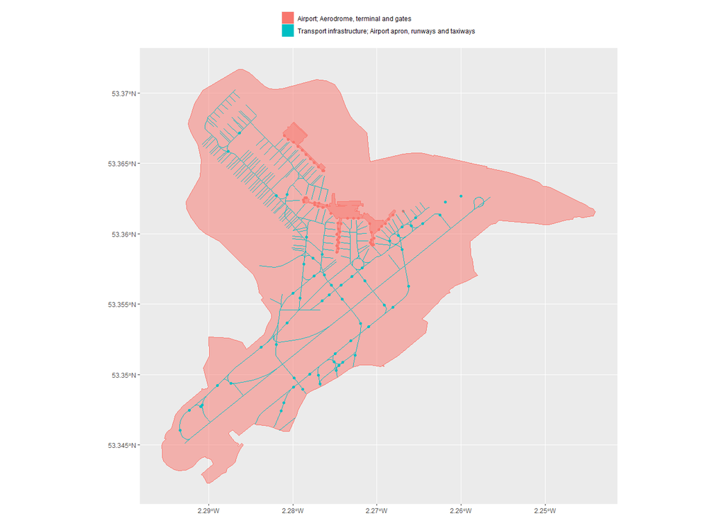

```r
example_airportBefore
```

The function accepts the following arguments:

- *dg* The valid geodata as a spatial feature
- *threshold_distanceBuildings = 1000* Relative proximity threshold for airport buildings. Represents the distance, in metres, below which objects should be considered as a single airport
- *threshold_distanceInfrastructure = 2500* Proximity threshold for airport infrastructure (relative to the airport buildings). Represents the distance, in metres, below which objects should be considered as part of a given airport
- *threshold_outline = 0.5* Ratio threshold for polygons to separate airport boundaries from buildings
- *threshold_area = 1000* Area, in square metres, above which an airport is classified as major. If an airport boundary is determined, this value is used, otherwise the area is the sum of the areas of all buildings for a given airport
- *rbind = TRUE* Should the simplified objects be provided as the output (FALSE) or bound to the filtered input (TRUE)

```r
airportBefore <- dm %>% filter(str_detect(desc, "Airport"))
airportAfter <- dm %>% simplifyAirports(rbind = FALSE)
airportBefore
```

```
#> Simple feature collection with 351 features and 2 fields
#> geometry type:  GEOMETRY
#> dimension:      XY
#> bbox:           xmin: -2.295565 ymin: 53.34228 xmax: -2.244002 ymax: 53.37168
#> geographic CRS: WGS 84
#> First 10 features:
#>                                                             desc  type
#> 1  Transport infrastructure; Airport apron, runways and taxiways POINT
#> 2  Transport infrastructure; Airport apron, runways and taxiways POINT
#> 3  Transport infrastructure; Airport apron, runways and taxiways POINT
#> 4  Transport infrastructure; Airport apron, runways and taxiways POINT
#> 5  Transport infrastructure; Airport apron, runways and taxiways POINT
#> 6  Transport infrastructure; Airport apron, runways and taxiways POINT
#> 7  Transport infrastructure; Airport apron, runways and taxiways POINT
#> 8  Transport infrastructure; Airport apron, runways and taxiways POINT
#> 9  Transport infrastructure; Airport apron, runways and taxiways POINT
#> 10 Transport infrastructure; Airport apron, runways and taxiways POINT
#>                      geometry
#> 1  POINT (-2.276772 53.34934)
#> 2  POINT (-2.293399 53.34603)
#> 3  POINT (-2.290729 53.34783)
#> 4  POINT (-2.262496 53.36133)
#> 5  POINT (-2.268461 53.35948)
#> 6  POINT (-2.276265 53.35707)
#> 7   POINT (-2.29232 53.34748)
#> 8  POINT (-2.290935 53.34774)
#> 9  POINT (-2.287329 53.34939)
#> 10 POINT (-2.283772 53.35194)
```

```r
airportAfter
```

```
#> Simple feature collection with 238 features and 2 fields
#> geometry type:  GEOMETRY
#> dimension:      XY
#> bbox:           xmin: -2.295565 ymin: 53.34228 xmax: -2.244002 ymax: 53.37168
#> geographic CRS: WGS 84
#> First 10 features:
#>                                                                   desc
#> 1       Major airport; Aerodrome, terminal and gates (Airport outline)
#> 2      Major airport; Aerodrome, terminal and gates (Building outline)
#> 3      Major airport; Aerodrome, terminal and gates (Building outline)
#> 4      Major airport; Aerodrome, terminal and gates (Building outline)
#> 5      Major airport; Aerodrome, terminal and gates (Building outline)
#> 6  Transport infrastructure; Major airport apron, runways and taxiways
#> 7  Transport infrastructure; Major airport apron, runways and taxiways
#> 8  Transport infrastructure; Major airport apron, runways and taxiways
#> 9  Transport infrastructure; Major airport apron, runways and taxiways
#> 10 Transport infrastructure; Major airport apron, runways and taxiways
#>          type                       geometry
#> 1     POLYGON POLYGON ((-2.290881 53.3429...
#> 2     POLYGON POLYGON ((-2.280578 53.3675...
#> 3     POLYGON POLYGON ((-2.274222 53.3610...
#> 4     POLYGON POLYGON ((-2.270393 53.3599...
#> 5     POLYGON POLYGON ((-2.274222 53.3610...
#> 6  LINESTRING LINESTRING (-2.281549 53.34...
#> 7  LINESTRING LINESTRING (-2.278362 53.34...
#> 8  LINESTRING LINESTRING (-2.276804 53.35...
#> 9  LINESTRING LINESTRING (-2.274688 53.34...
#> 10 LINESTRING LINESTRING (-2.272847 53.35...
```

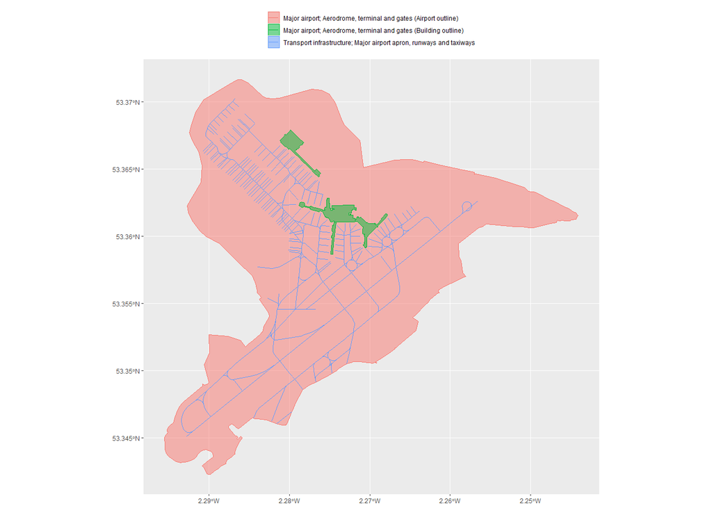

```r
example_airportAfter
```

```r
dm %>% nrow()
```

```
#> [1] 58796
```

```r
dm <- dm %>% simplifyAirports(rbind = TRUE)
dm %>% nrow()
```

```
#> [1] 59034
```

```r
dm %>% tail
```

```
#> Simple feature collection with 6 features and 2 fields
#> geometry type:  LINESTRING
#> dimension:      XY
#> bbox:           xmin: -2.29021 ymin: 53.36753 xmax: -2.287687 ymax: 53.36922
#> geographic CRS: WGS 84
#>                                                                      desc
#> 59029 Transport infrastructure; Major airport apron, runways and taxiways
#> 59030 Transport infrastructure; Major airport apron, runways and taxiways
#> 59031 Transport infrastructure; Major airport apron, runways and taxiways
#> 59032 Transport infrastructure; Major airport apron, runways and taxiways
#> 59033 Transport infrastructure; Major airport apron, runways and taxiways
#> 59034 Transport infrastructure; Major airport apron, runways and taxiways
#>             type                       geometry
#> 59029 LINESTRING LINESTRING (-2.287687 53.36...
#> 59030 LINESTRING LINESTRING (-2.288162 53.36...
#> 59031 LINESTRING LINESTRING (-2.288618 53.36...
#> 59032 LINESTRING LINESTRING (-2.289018 53.36...
#> 59033 LINESTRING LINESTRING (-2.289342 53.36...
#> 59034 LINESTRING LINESTRING (-2.288921 53.36...
```

### 2.3 exportOSMtidy()

The exportOSMtidy() function can be used once makeValid() has been applied, or after the simplify family. As with the functions central to OSMtidy’s workflow, the file name is a combination of the location name and time stamps with the final output being exported to the *outputs* folder. Three types of output may be exported:

- “.RDS” For when the output is to be used within the R environment
- “.csv” Outputs a two column spreadsheet for use in any software environment
- “.shp” Three shapefiles are generated - each capturing a geometry type (point, line and polygon)

```r
dm %>% exportOSMtidy("Manchester_City", type = ".RDS")
```

```
#> Files saved as:
#>
#>  outputs/Manchester_City_postProcessing_20200813-101128.RDS
```

```r
dm %>% exportOSMtidy("Manchester_City", type = ".csv")
```

```
#> Files saved as:
#>
#>  outputs/Manchester_City_postProcessing_20200813-101128.csv
```

```r
dm %>% exportOSMtidy("Manchester_City", type = ".shp")
```

```
#> Files saved as:
#>
#>  outputs/Manchester_City_postProcessing_POINT_20200813-101130.shp
#>  outputs/Manchester_City_postProcessing_LINESTRING_20200813-101130.shp
#>  outputs/Manchester_City_postProcessing_POLYGON_20200813-101131.shp
```

## 3. Example two - Edinburgh

The Edinburgh example primarily serves to highlight the value of the `simplifyAirports()` function. First the data must be validated. Note, the slower version of `makeValid()` is called (internally) to process the Edinburgh geodata.

```r
file <- list.files("vignettes/files/postProcessing", pattern = "Edinburgh", full.names = TRUE)
file
```

```
#> [1] "vignettes/files/postProcessing/Edinburgh_City_6_dataTidy-filtered_20200712-152303.RDS"
```

```r
de <- readRDS(file)
de %>% nrow()
```

```
#> [1] 304084
```

```r
de <- de %>% makeValid
de %>% nrow()
```

```
#> [1] 307268
```

```r
airportBefore <- de %>% filter(str_detect(desc, "Airport"))
airportBefore
```

```
#> Simple feature collection with 212 features and 2 fields
#> geometry type:  GEOMETRY
#> dimension:      XY
#> bbox:           xmin: -3.410838 ymin: 55.87115 xmax: -3.323811 ymax: 55.95948
#> geographic CRS: WGS 84
#> First 10 features:
#>                                                             desc  type
#> 1  Transport infrastructure; Airport apron, runways and taxiways POINT
#> 2  Transport infrastructure; Airport apron, runways and taxiways POINT
#> 3  Transport infrastructure; Airport apron, runways and taxiways POINT
#> 4  Transport infrastructure; Airport apron, runways and taxiways POINT
#> 5  Transport infrastructure; Airport apron, runways and taxiways POINT
#> 6  Transport infrastructure; Airport apron, runways and taxiways POINT
#> 7  Transport infrastructure; Airport apron, runways and taxiways POINT
#> 8  Transport infrastructure; Airport apron, runways and taxiways POINT
#> 9  Transport infrastructure; Airport apron, runways and taxiways POINT
#> 10 Transport infrastructure; Airport apron, runways and taxiways POINT
#>                      geometry
#> 1  POINT (-3.348263 55.95033)
#> 2  POINT (-3.347431 55.95008)
#> 3  POINT (-3.346548 55.94984)
#> 4  POINT (-3.352291 55.95117)
#> 5  POINT (-3.352461 55.95121)
#> 6  POINT (-3.353018 55.95135)
#> 7  POINT (-3.353523 55.95154)
#> 8  POINT (-3.353983 55.95181)
#> 9  POINT (-3.354579 55.95197)
#> 10 POINT (-3.355166 55.95216)
```

```r
airportAfter <- de %>% simplifyAirports(rbind = FALSE)
airportAfter
```

```
#> Simple feature collection with 131 features and 2 fields
#> geometry type:  GEOMETRY
#> dimension:      XY
#> bbox:           xmin: -3.410838 ymin: 55.87115 xmax: -3.323811 ymax: 55.95948
#> geographic CRS: WGS 84
#> First 10 features:
#>                                                                   desc
#> 1       Major airport; Aerodrome, terminal and gates (Airport outline)
#> 2      Major airport; Aerodrome, terminal and gates (Building outline)
#> 3      Major airport; Aerodrome, terminal and gates (Building outline)
#> 4      Major airport; Aerodrome, terminal and gates (Building outline)
#> 5  Transport infrastructure; Major airport apron, runways and taxiways
#> 6  Transport infrastructure; Major airport apron, runways and taxiways
#> 7  Transport infrastructure; Major airport apron, runways and taxiways
#> 8  Transport infrastructure; Major airport apron, runways and taxiways
#> 9  Transport infrastructure; Major airport apron, runways and taxiways
#> 10 Transport infrastructure; Major airport apron, runways and taxiways
#>          type                       geometry
#> 1     POLYGON POLYGON ((-3.399091 55.9415...
#> 2     POLYGON POLYGON ((-3.359416 55.9481...
#> 3     POLYGON POLYGON ((-3.361801 55.9484...
#> 4     POLYGON POLYGON ((-3.361612 55.9493...
#> 5  LINESTRING LINESTRING (-3.355112 55.95...
#> 6  LINESTRING LINESTRING (-3.353629 55.95...
#> 7  LINESTRING LINESTRING (-3.364921 55.95...
#> 8  LINESTRING LINESTRING (-3.379763 55.94...
#> 9  LINESTRING LINESTRING (-3.349688 55.94...
#> 10 LINESTRING LINESTRING (-3.388718 55.94...
```

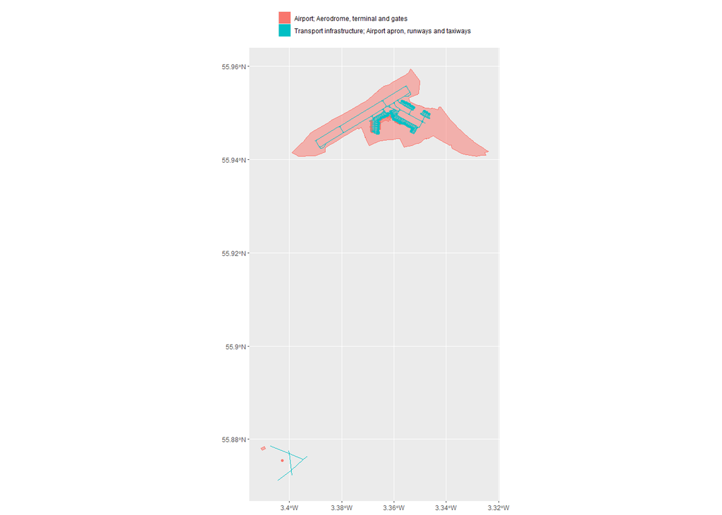

```r
example_airportBefore <-
de %>%
    filter(str_detect(desc, "Airport")) %>%
    ggplot(aes(colour = desc, fill = desc)) +
    geom_sf(data = . %>% filter(type == "POLYGON"), alpha = 0.5, ) +
    geom_sf(data = . %>% filter(type != "POLYGON")) +
  theme(legend.position = "top",
        legend.title = element_blank(),
        legend.direction = "vertical")
example_airportBefore
```

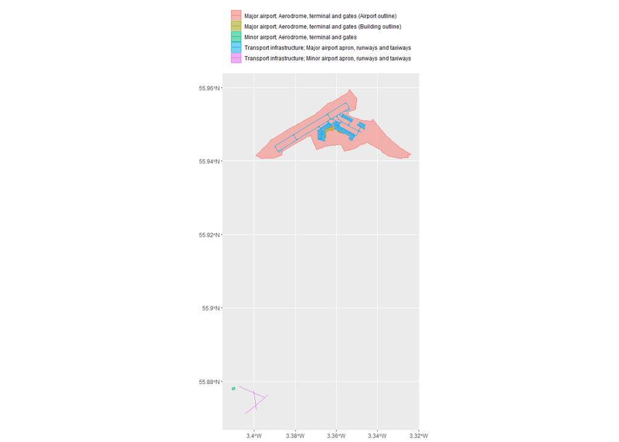

```r
example_airportAfter <-
de %>%
    simplifyAirports(rbind = FALSE) %>%
    ggplot(aes(colour = desc, fill = desc)) +
    geom_sf(data = . %>% filter(type == "POLYGON"), alpha = 0.5, ) +
    geom_sf(data = . %>% filter(type != "POLYGON")) +
  theme(legend.position = "top",
        legend.title = element_blank(),
        legend.direction = "vertical")
example_airportAfter
```